# IODS course project

Strong negative correlation between distances to five Boston employment centres (dis) and proportion of owner-occupied units built prior to 1940 (age), between distances to five Boston employment centres (dis) and nitrogen oxides concentration (nox), between distances to five Boston employment centres (dis) and proportion of non-retail business acres per town (indus), and between median value of owner-occupied homes (medv) and lower status of the population (lstat).

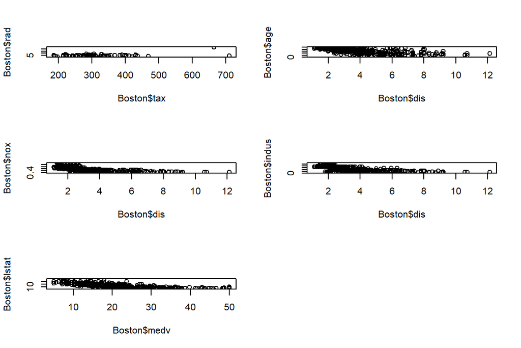

```r
par(mfrow=c(3,2))
plot(Boston$tax,Boston$rad)
plot(Boston$dis,Boston$age)
plot(Boston$dis,Boston$nox)
plot(Boston$dis,Boston$indus)
plot(Boston$medv,Boston$lstat)
```

Scatter plots of the strongest correlations.

**4 Standardize the dataset**

```r
boston_scaled <- scale(Boston)
boston_scaled <- as.data.frame(boston_scaled)
summary(boston_scaled)
```

```
##       crim                 zn               indus
##  Min.   :-0.419367   Min.   :-0.48724   Min.   :-1.5563
##  1st Qu.:-0.410563   1st Qu.:-0.48724   1st Qu.:-0.8668
##  Median :-0.390280   Median :-0.48724   Median :-0.2109
##  Mean   : 0.000000   Mean   : 0.00000   Mean   : 0.0000
##  3rd Qu.: 0.007389   3rd Qu.: 0.04872   3rd Qu.: 1.0150
##  Max.   : 9.924110   Max.   : 3.80047   Max.   : 2.4202
##       chas              nox                rm               age
##  Min.   :-0.2723   Min.   :-1.4644   Min.   :-3.8764   Min.   :-2.3331
##  1st Qu.:-0.2723   1st Qu.:-0.9121   1st Qu.:-0.5681   1st Qu.:-0.8366
##  Median :-0.2723   Median :-0.1441   Median :-0.1084   Median : 0.3171
##  Mean   : 0.0000   Mean   : 0.0000   Mean   : 0.0000   Mean   : 0.0000
##  3rd Qu.:-0.2723   3rd Qu.: 0.5981   3rd Qu.: 0.4823   3rd Qu.: 0.9059
##  Max.   : 3.6648   Max.   : 2.7296   Max.   : 3.5515   Max.   : 1.1164
##       dis               rad               tax             ptratio
##  Min.   :-1.2658   Min.   :-0.9819   Min.   :-1.3127   Min.   :-2.7047
##  1st Qu.:-0.8049   1st Qu.:-0.6373   1st Qu.:-0.7668   1st Qu.:-0.4876
##  Median :-0.2790   Median :-0.5225   Median :-0.4642   Median : 0.2746
##  Mean   : 0.0000   Mean   : 0.0000   Mean   : 0.0000   Mean   : 0.0000
##  3rd Qu.: 0.6617   3rd Qu.: 1.6596   3rd Qu.: 1.5294   3rd Qu.: 0.8058
##  Max.   : 3.9566   Max.   : 1.6596   Max.   : 1.7964   Max.   : 1.6372
##      black             lstat              medv
##  Min.   :-3.9033   Min.   :-1.5296   Min.   :-1.9063
##  1st Qu.: 0.2049   1st Qu.:-0.7986   1st Qu.:-0.5989
##  Median : 0.3808   Median :-0.1811   Median :-0.1449
##  Mean   : 0.0000   Mean   : 0.0000   Mean   : 0.0000
##  3rd Qu.: 0.4332   3rd Qu.: 0.6024   3rd Qu.: 0.2683
##  Max.   : 0.4406   Max.   : 3.5453   Max.   : 2.9865
```

All variables have mean 0.

```r
# create a quantile vector of crim
bins <- quantile(boston_scaled$crim)

# create a categorical variable 'crime'
crime <- cut(boston_scaled$crim, breaks = bins, include.lowest = TRUE,label=c("low","med_low","med_high","high"))

# remove original crim from the dataset
boston_scaled <- dplyr::select(boston_scaled, -crim)

# add the new categorical value to scaled data
boston_scaled <- data.frame(boston_scaled, crime)

# number of rows in the Boston dataset
n <- nrow(boston_scaled)

# choose randomly 80% of the rows
ind <- sample(n,  size = n * 0.8)

# create train set
train <- boston_scaled[ind,]

# create test set
test <- boston_scaled[-ind,]
```

**5 Linear discriminant analysis**

```r
lda.fit <- lda(crime ~ ., data = train)
lda.fit
```

```
## Call:
## lda(crime ~ ., data = train)
##
## Prior probabilities of groups:
##       low   med_low  med_high      high
## 0.2400990 0.2574257 0.2475248 0.2549505
##
## Group means:
##                   zn      indus       chas        nox          rm
## low       0.95290116 -0.8687563 -0.1099744 -0.8732654  0.41392319
## med_low  -0.08629773 -0.3285110 -0.0830454 -0.5800535 -0.11625458
## med_high -0.39205294  0.1859994  0.2001230  0.3643924  0.01671695
## high     -0.48724019  1.0170891 -0.0812077  1.0165062 -0.50209424
##                 age        dis        rad        tax     ptratio
## low      -0.9290685  0.9171099 -0.6941624 -0.7343363 -0.41660418
## med_low  -0.3770441  0.3839996 -0.5434660 -0.4999848 -0.04474928
## med_high  0.4413357 -0.3781801 -0.4397948 -0.3264394 -0.20718008
## high      0.8243225 -0.8453302  1.6384176  1.5142626  0.78111358
##                black       lstat         medv
## low       0.37450859 -0.77248490  0.506006192
## med_low   0.31838727 -0.16175221  0.009606015
## med_high  0.09461615  0.02689191  0.089505747
## high     -0.79131571  0.91381058 -0.665552524
##
## Coefficients of linear discriminants:
##                  LD1         LD2         LD3
## zn       0.103332984  0.64590845 -1.06654887
## indus    0.054272085 -0.10887893  0.08988689
## chas    -0.117676948 -0.08066388  0.02400094
## nox      0.395733564 -0.63588554 -1.34134609
## rm      -0.130817488 -0.07009798 -0.14288855
## age      0.195524277 -0.42263927 -0.21338660
## dis     -0.086799864 -0.06943255  0.04704322
## rad      3.410772991  1.03237198 -0.12559241
## tax      0.005378223 -0.13719217  0.67744083
## ptratio  0.128967428  0.01562933 -0.29979280
## black   -0.115795800  0.01373184  0.14303434
## lstat    0.208583736 -0.13106910  0.35994313
## medv     0.204166899 -0.24811986 -0.19166056
##
## Proportion of trace:
##    LD1    LD2    LD3
## 0.9559 0.0337 0.0105
```

LD1 explains 95% of the between group variance.

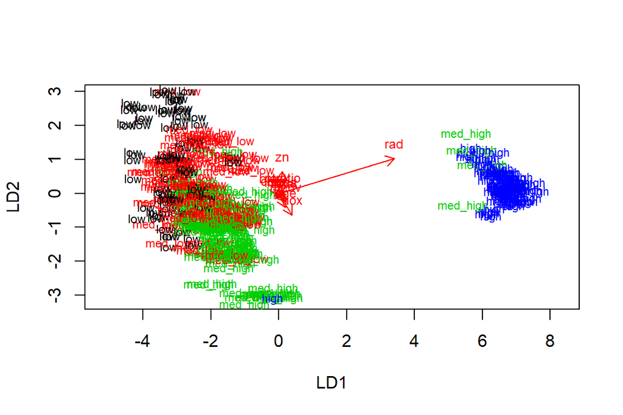

```r
# target classes as numeric (for plotting purposes)
classes <- as.numeric(train$crime)

# the function for lda biplot arrows
lda.arrows <- function(x, myscale = 1, arrow_heads = 0.1, color = "red", tex = 0.75, choices = c(1,2)){
heads <- coef(x)
  arrows(x0 = 0, y0 = 0,
x1 = myscale * heads[,choices[1]],
 y1 = myscale * heads[,choices[2]], col=color, length = arrow_heads)
  text(myscale * heads[,choices], labels = row.names(heads),   cex = tex, col=color, pos=3)
}


plot(lda.fit, dimen = 2, col = classes, pch = classes)
lda.arrows(lda.fit, myscale = 1)
```

The class “high” is a distinct class, whereas there is some overlapping for the rest of the classes. Variables “rad”, “zn”, and “nox” affect the classification the most.